# 5. praktikum

## 2. kiht: graafiku tüüp (*geom*)

Teine kiht täpsustab, **millist graafiku tüüpi** mingi tunnuse või tunnuste kuvamiseks kasutada. Seda kihti nimetatakse `geom_function`’iks. Levinumad **geom**’id on

- `geom_point()` (hajuvusdiagrammid),
- `geom_count()` (hajuvusdiagrammid, kus kattuvad punktid on suuremad),
- `geom_histogram()` (histogrammid),
- `geom_boxplot()` (karpdiagrammid),
- `geom_bar()` (tulpdiagrammid, kui sagedused tuleb arvutada),
- `geom_col()` (tulpdiagrammid, kui sagedused on juba arvutatud),
- `geom_label()` (sildid),
- `geom_text()` (tekst),
- `geom_line()` (joondiagrammid),
- `geom_smooth()` (trendijooned),
- jne.

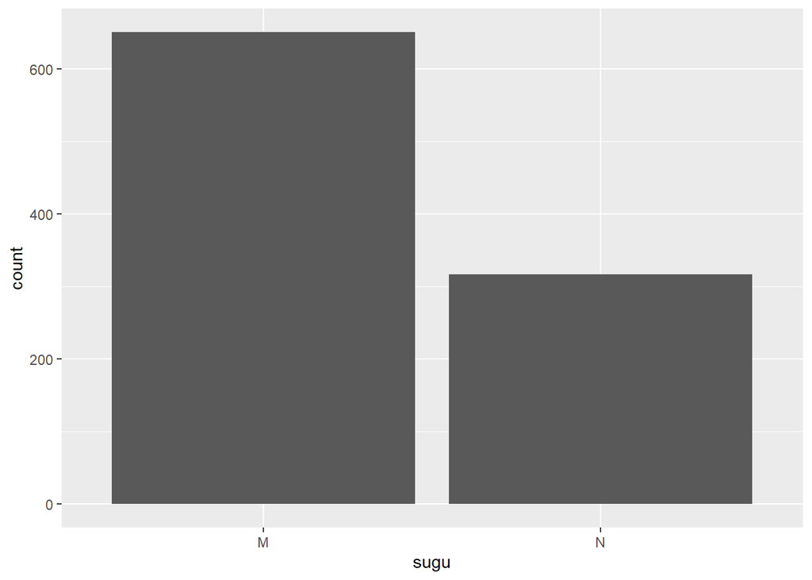

```r
# Jätame ära argumentide nimed "data" ja "mapping"
ggplot(valimised,
       aes(x = sugu)) +
  geom_bar()

# Käsku võib lugeda nii:
# kasuta andmestikust 'valimised'
# graafiku x-teljel kuvamiseks
# tunnust 'sugu' nii,
# et graafiku tüübiks on tulpdiagramm.
```

**`geom_bar()`** on funktsioon, mis loeb kategoriaalse tunnuse tasemed vaikimisi kokku ja paneb y-teljele tasemete sagedused, ilma et peaksime sageduste leidmiseks esmalt nt `table()`-funktsiooni kasutama ja seda `data.frame`’iks teisendama (vrd nt baasgraafika `barplot()` funktsiooniga, mis nõuab sisendiks sagedustega `table`-objekti).

**Kui andmestikus oleks juba eraldi tulp sagedustega**, peaksime `aes()`-funktsioonis täpsustama selle tulba y-argumendi väärtusena (`y = sageduste_tulp`) ning kasutama `geom_bar()` funktsiooni sees argumenti `stat = "identity"` või kasutama `geom_bar()` asemel funktsiooni **`geom_col()`**.

```r
ggplot(data.frame(table(valimised$sugu)),
       aes(x = Var1, y = Freq)) + # y-teljel sagedused
  geom_bar(stat = "identity")

# või
ggplot(data.frame(table(valimised$sugu)),
       aes(x = Var1, y = Freq)) +
  geom_col()
```

Sellisest sagedustega andmestikust saab teha ka piruka ehk sektordiagrammi.

```r
ggplot(data.frame(table(valimised$sugu)),
       aes(x = "", y = Freq, fill = Var1)) +
  geom_col() +
  coord_polar(theta = "y")
```

Sektordiagrammide jaoks on aga parem ggploti täiendav pakett [`ggtricks`](https://cran.r-project.org/web/packages/ggtricks/readme/README.html), milles on funktsioon `geom_pie()`.

Nagu öeldud, võib `data`’t ja tunnuste `mapping`’ut täpsustada ka `geom`-kihtides. Näiteks ülal oleva graafiku saame ka sellise koodiga:

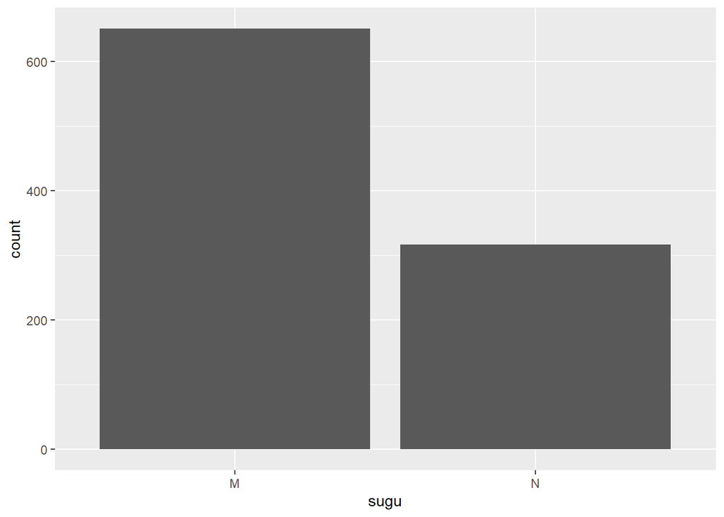

```r
ggplot() +
  geom_bar(data = valimised,
           aes(x = sugu))
```

Sellisel juhul ei eeldata, et iga lisatud kiht kasutab täpselt sama andmestikku ja samu tunnuseid, vaid iga kiht võib kasutada **erinevaid andmestikke** või **sama andmestiku erinevaid alamhulki**.

Näiteks võime samal graafikul kujutada lisaks eraldi **joonega** ainult mingi valimisnimekirja, nt sotsiaaldemokraatide mees- ja naiskandidaatide arvu. **`geom_line`** on nn kollektiivne *geom* ehk selle joonistamiseks kasutatakse mitme vaatluse andmeid (joont ei saa joonistada ainult 1 vaatluse põhjal). Selleks, et joon oleks tõmmatud üle kõikide kategooriate (siin mees- ja naiskandidaatide tulpade), kasutame `geom_line()` funktsiooni sees argumenti `group`.

Kui joone tõmbamiseks vajalikke vaatlusi ei grupeeri mingi andmestiku tunnus, võib `group`’i väärtus olla mis tahes konstant, nt 1, 500, “a”, “konstant” vmt.

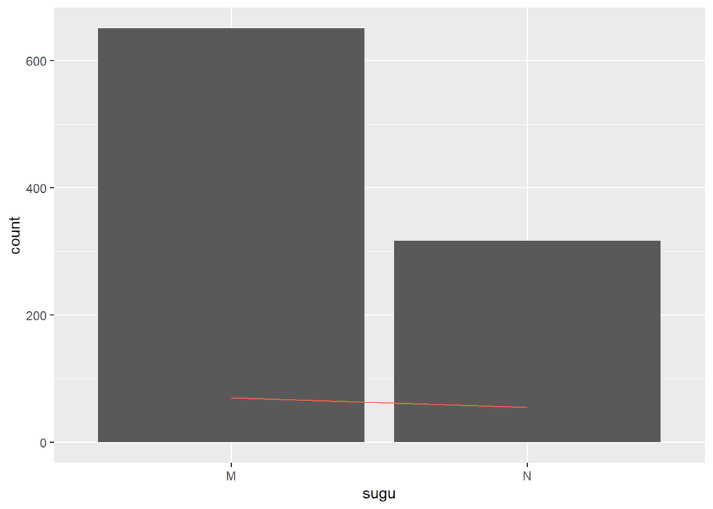

```r
# stat = "count" tuleb lisada, et
# ggplot teaks, kust tulevad joone jaoks y-teljele sagedused
# ("count" ehk "loe kokku").

ggplot() +
  geom_bar(data = valimised,
           aes(x = sugu)) +
  geom_line(data = valimised[valimised$nimekiri == "Sotsiaaldemokraatlik Erakond",],
            aes(x = sugu),
            stat = "count",
            color = "tomato1",
            group = 1) # vaatame küll ainult sotside nimekirja kandidaate, aga neid omakorda edasi ei grupeeri ükski andmestiku tunnus (group = konstant)
```

Kui aga tahta grupeerida vaatlusi mingi andmestiku tunnuse järgi (nt valimisnimekiri) ning näidata seega **kõiki** selle tunnuse alusel tekkivaid andmestiku alamosi korraga, tuleb `group`-argument liigutada `aes()` funktsiooni sisse ning argumendi väärtuseks panna seesama andmestiku tunnus ise.  
Sel juhul ei tule iga tunnuse taseme kohta tekitada uut `geom`-kihti omaette alamandmestikuga (nt `valimised[valimised$nimekiri == "Sotsiaaldemokraatlik Erakond",]`, `valimised[valimised$nimekiri == "Eesti Reformierakond",]` jne). Kuvame näiteks kõikide erakondade mees- ja naiskandidaatide arvu üldiste tulpade peal eri värvi joontena.

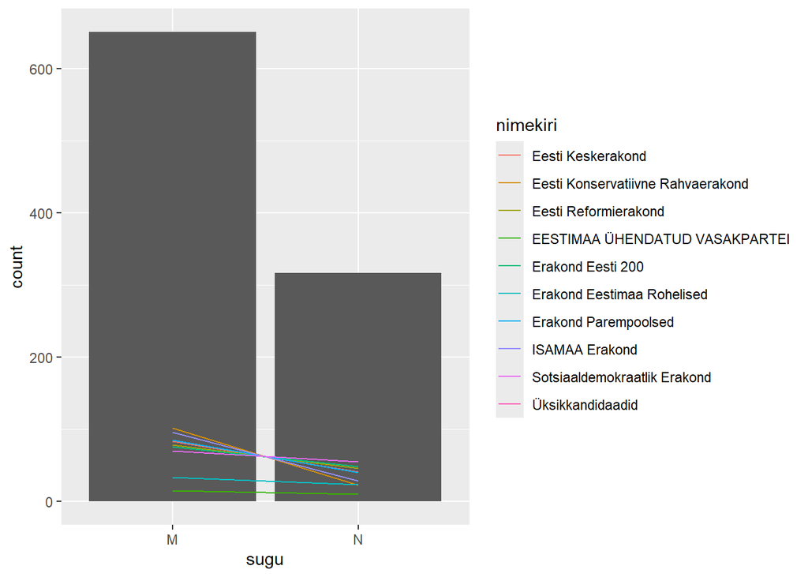

```r
ggplot() +
  geom_bar(data = valimised,
           aes(x = sugu)) +
  geom_line(data = valimised,
            aes(x = sugu,
                group = nimekiri, # grupeeriv tunnus
                color = nimekiri), # värvime ka jooned grupeeriva tunnuse järgi (värv nüüd aes()-funktsiooni sees!)
            stat = "count")
```

```r
# Need data ja aes osad, mis kahel geom-kihil kattuvad
# (data = valimised ja aes(x = sugu)),
# võib liigutada ka lihtsalt ggplot()-funktsiooni sisse
ggplot(valimised, aes(x = sugu)) +
  geom_bar() +
  geom_line(aes(group = nimekiri,
                color = nimekiri),
            stat = "count")
```

Võrdle:

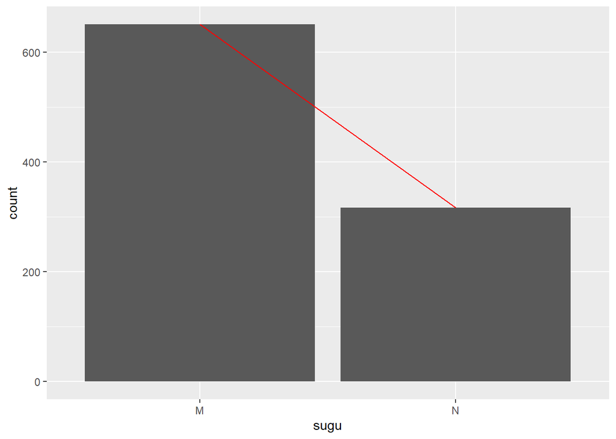

```r
ggplot(valimised, aes(x = sugu)) +
  geom_bar() +
  geom_line(aes(group = 1), # grupeeriv konstant
            color = "red", # joone värv ei sõltu mingist andmestiku tunnusest
            stat = "count")
```

### Harjuta

Laadi RStudiosse eelmistes praktikumides kasutatud küsimustik. Loo `ggplot`’i kiht, kus x-teljel oleks sünniaasta ja y-teljel oleks õpitud aastate arv.  
Kuva sünniaasta ja õpitud aastate arvu suhet hajuvusdiagrammil.

## 3. kiht: tunnuste väljanägemine graafikul (*scale*)

Kolmas kiht lubab modifitseerida seda, **kuidas** mingil kujul graafikul esitamiseks valitud tunnus graafikul täpselt välja näeb. Seda kihti nimetatakse `scale_function`’iks.

`scale`’iga saab modifitseerida konkreetselt seda elementi, mille kaudu tunnust graafikul kujutatud on, nt `scale_x_...`, `scale_y_...`, `scale_color_...`, `scale_fill_...`, `scale_size_...`, `scale_shape_...`, `scale_alpha_...`, `scale_linetype_...` jne.

`scale`-funktsiooni nime viimane element (üleval märgitud praegu punktiiriga) kirjeldab tunnuse modifitseerimise tüüpi, värviskaalat vms. See, mis argumendid mingil konkreetsel `scale`-funktsioonil on, sõltub funktsioonist endast. Trüki konsooli nt `scale_` ja vajuta tabulaatorit, et näha erinevaid variante.

Kasutame siin `scale`-funktsiooni, et nimetada soo tasemeid graafiku **x-teljel** pikemalt (vastavalt sõnadega *mehi* ja *naisi*) ja kasutada valimisnimekirja joontena kuvamiseks ggploti vaikimisi pakutud **värvide** asemel enda määratud värve. Värvivektoris võib värve määrata kas värvinimede kaudu (nt `c("red", "blue")`, vt ka `colors()`), hex-värvikoodide kaudu (nt `c("#FF0000", "#0000FF")`) või määrates eraldi punase, rohelise ja sinise tooni suhte funktsioonis `rgb()` (nt `rgb(red = 0, blue = 255, green = 0, maxColorValue = 255)`).

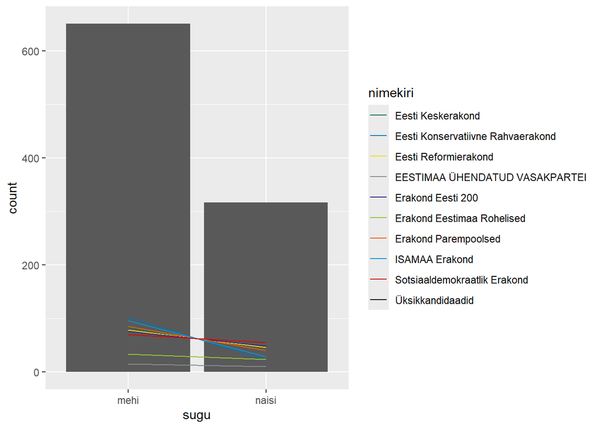

```r
ggplot(valimised, aes(x = sugu)) +
  geom_bar() +
  geom_line(aes(group = nimekiri, color = nimekiri), stat = "count") +
  scale_x_discrete(labels = c("mehi", "naisi")) +
  scale_color_manual(values = c("#007154", "#0073B7", "#F7DB00", "#858C92", "#2E2990", "#91C33C", "#F75E00", "#0594DA", "#DA0600", "#000000"))

# 'labels'-argument nimetab joonisel soo tasemed ümber (aga mitte andmestikus!)
# 'scale_color_manual' laseb määrata tunnuse tasemetele käsitsi uued värvid
```

`color` täpsustab ggplotis joonte (nt joongraafiku või tulpade jm-de kujundite piirjoonte) värvi. Täitevärvi jaoks on ggplotis `aes`-funktsiooni argument nimega `fill`. Kujutame nüüd tulpdiagrammi x-teljel hoopis nimekirja ja sugu tulpade täitevärvina (`fill`). Tahtes määrata vaikimisi täitevärvide asemel muid värve, tuleb sellisel juhul täpsustada seda kihil, mis algab tekstiga `scale_fill_...`. Võime määrata värvid taas kord käsitsi, kui kasutame funktsiooni `scale_fill_manual(values = c("värv1", "värv2"))` või kasutada juba mõnd olemasolevat värvipaletti, nt [ColorBreweri](https://r-graph-gallery.com/38-rcolorbrewers-palettes.html) omade hulgast.

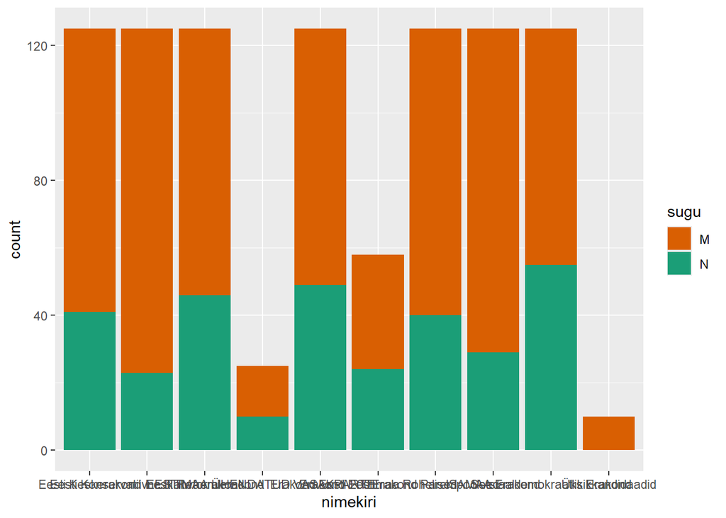

```r
ggplot(valimised, aes(x = nimekiri, fill = sugu)) +
  geom_bar() +
  scale_fill_brewer(type = "qual", # kvalitatiivne tunnus
                    palette = 2, # 2. värvipalett
                    direction = -1) # keera palett vastupidi
```

Vaikimisi sätitakse soo kategooriad üksteise otsa (`position = "stack"`). Võime aga `geom_bar()` funktsiooni sees täpsustada, et

1. eri kategooriate tulbad võiksid olla hoopis **üksteise kõrval** (`geom_bar(position = "dodge")`) või et
2. vaatleme absoluutsageduste asemel hoopis **proportsioone**, st seda, kui suured on ühe või teise nimekirja mees- ja naiskandidaatide osakaalud (`geom_bar(position = "fill")`).

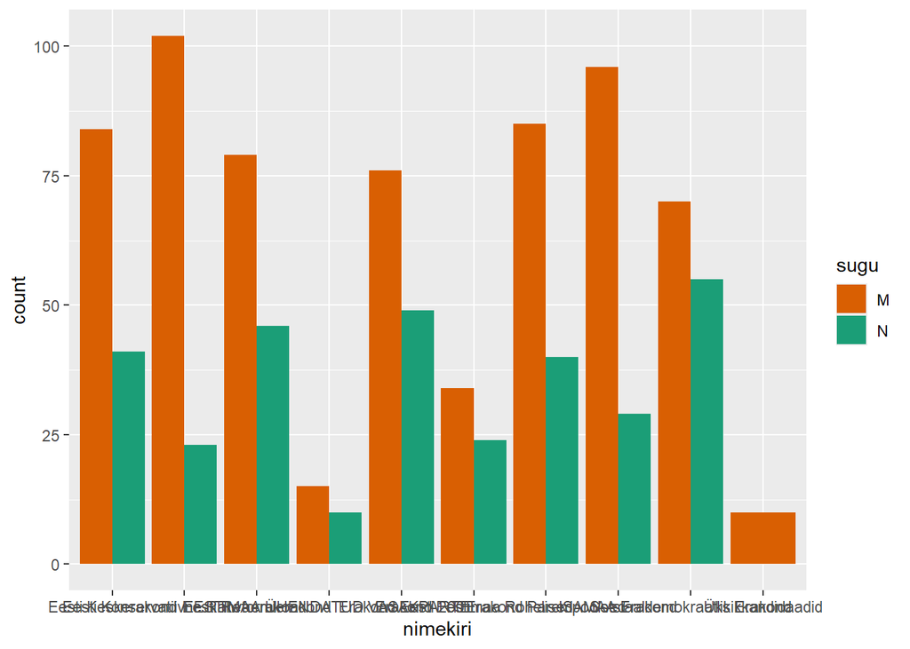

```r
ggplot(valimised, aes(x = nimekiri, fill = sugu)) +
  geom_bar(position = "dodge") + # meeste ja naiste tulbad kõrvuti
  scale_fill_brewer(type = "qual", palette = 2, direction = -1)
```

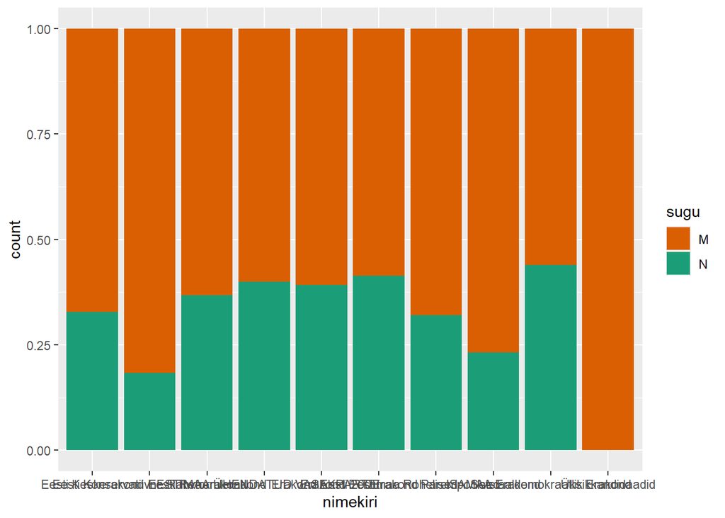

```r
ggplot(valimised, aes(x = nimekiri, fill = sugu)) +
  geom_bar(position = "fill") + # meeste ja naiste osakaalud
  scale_fill_brewer(type = "qual", palette = 2, direction = -1)
```

Kuna x-telje sildid kipuvad praegu üksteise peale jooksma, on üks variant keerata kogu joonis 90 kraadi paremale nii, et nimekirjade sildid jääksid x-telje asemel y-teljele.

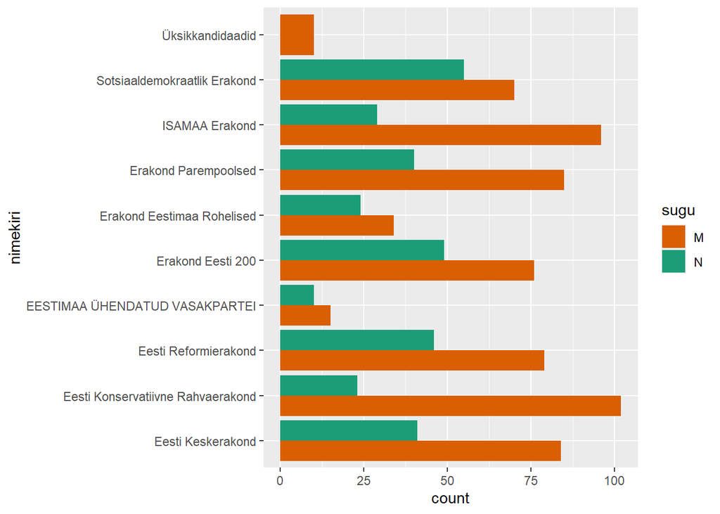

```r
ggplot(valimised, aes(y = nimekiri, fill = sugu)) +
  geom_bar(position = "dodge") +
  scale_fill_brewer(type = "qual", palette = 2, direction = -1)
```

```r
# või
ggplot(valimised, aes(x = nimekiri, fill = sugu)) +
  geom_bar(position = "dodge") +
  scale_fill_brewer(type = "qual", palette = 2, direction = -1) +
  coord_flip() # võib lisada ka funktsiooni, mis vahetab x- ja y-telje ära
```

Üks asi, mida kindlasti tulpdiagrammidega sageli vaja läheb, on **tulpade ümberjärjestamine**. Üks võrdlemisi kohmakas, aga lihtne ja läbipaistev viis seda teha on anda kategooriate järjekord tekstivektorina ette selle telje `scale`-kihil, kus järjestatavate kategooriate nimed on (meie näites `scale_y_...`). Näiteks kui tahame kuvada tulpasid selle põhjal, kui palju üldse nimekirjades kandidaate kokku on, saame leida selle esmalt `table()`-funktsiooniga, sorteerida sagedustabeli ja küsida sorteeritud tabeli kategooriate nimesid.

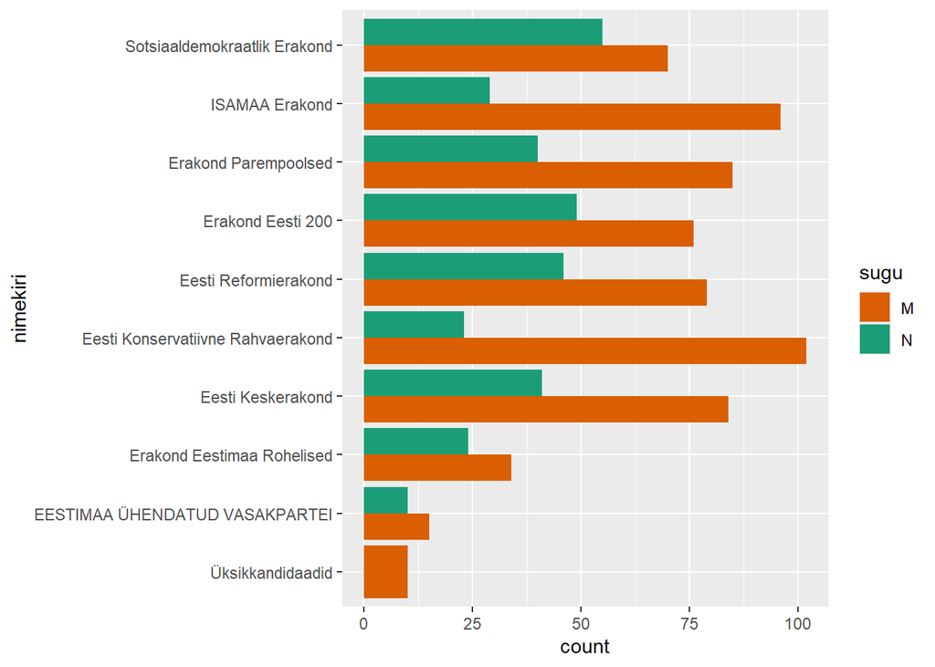

```r
t.nimekiri <- table(valimised$nimekiri)
kandidaate_kokku <- names(sort(t.nimekiri))

ggplot(valimised, aes(y = nimekiri, fill = sugu)) +
  geom_bar(position = "dodge") +
  scale_fill_brewer(type = "qual", palette = 2, direction = -1) +
  scale_y_discrete(limits = kandidaate_kokku) # limits argumendi väärtuseks on kategooriate puhul nende järjestatud vektor
```

Kui tahame sorteerida selle järgi, kui palju (absoluutarvuna) nimekirjas on naisi, peame tegema sama asja soo ja nimekirja risttabeli naiste reaga.

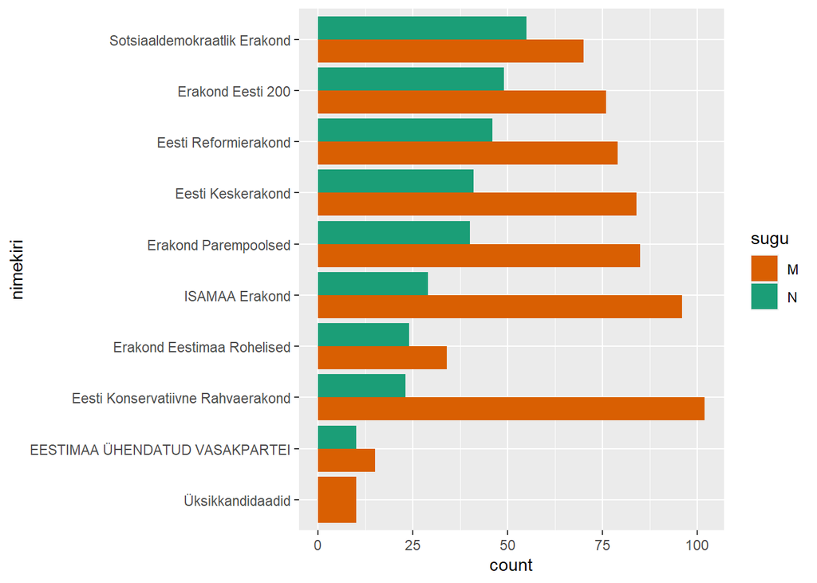

```r
t.sugu.nimekiri <- table(valimised$sugu, valimised$nimekiri)
naiskandidaate <- names(sort(t.sugu.nimekiri["N",]))

ggplot(valimised, aes(y = nimekiri, fill = sugu)) +
  geom_bar(position = "dodge") +
  scale_fill_brewer(type = "qual", palette = 2, direction = -1) +
  scale_y_discrete(limits = naiskandidaate)
```

Veelgi ausam oleks sorteerida selle põhjal, kui suur on nimekirjas naiskandidaatide **osakaal**.

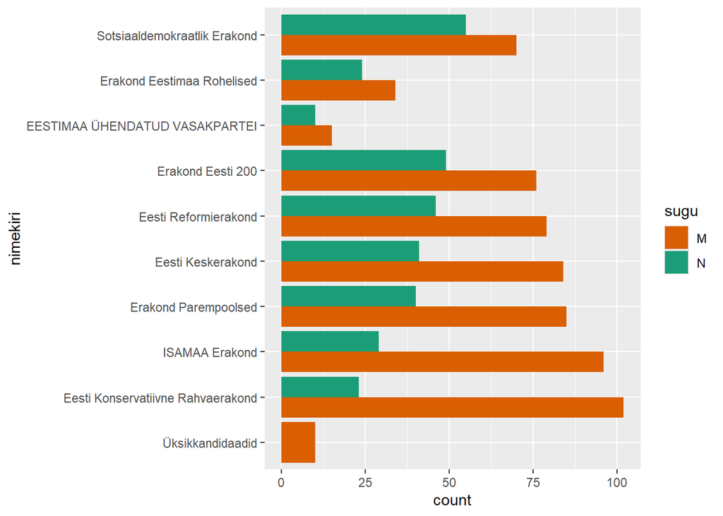

```r
t.sugu.nimekiri.props <- prop.table(t.sugu.nimekiri, margin = 2)
naiskandidaatide_osakaal <- names(sort(t.sugu.nimekiri.props["N",]))

ggplot(valimised, aes(y = nimekiri, fill = sugu)) +
  geom_bar(position = "dodge") +
  scale_fill_brewer(type = "qual", palette = 2, direction = -1) +
  scale_y_discrete(limits = naiskandidaatide_osakaal)
```

Teiste meetoditega kategooriate sorteerimisest võib lugeda rohkem näiteks [siit](https://r-graph-gallery.com/267-reorder-a-variable-in-ggplot2.html) või [siit](https://ggplot2.tidyverse.org/articles/faq-reordering.html).

### Harjuta

Laadi RStudiosse eelmistes praktikumides kasutatud küsimustik. Loo `ggplot`’i kiht, kus x-teljel oleks sünniaasta ja y-teljel oleks õpitud aastate arv.  
Kuva sünniaasta ja õpitud aastate arvu suhet hajuvusdiagrammil.  
Tähista erineva värviga need vastajad, kellel on kvantitatiivsete meetoditega kogemust, ja need, kellel ei ole. Kasuta kategooriate jaoks värve “grey45” ja “orange”.

## 4. kiht: selgitavad tekstid (*labs*)

Neljandal kihil võime täpsustada telgede ja graafikute pealkirjad, alapealkirjad jmt funktsiooniga `labs()`.

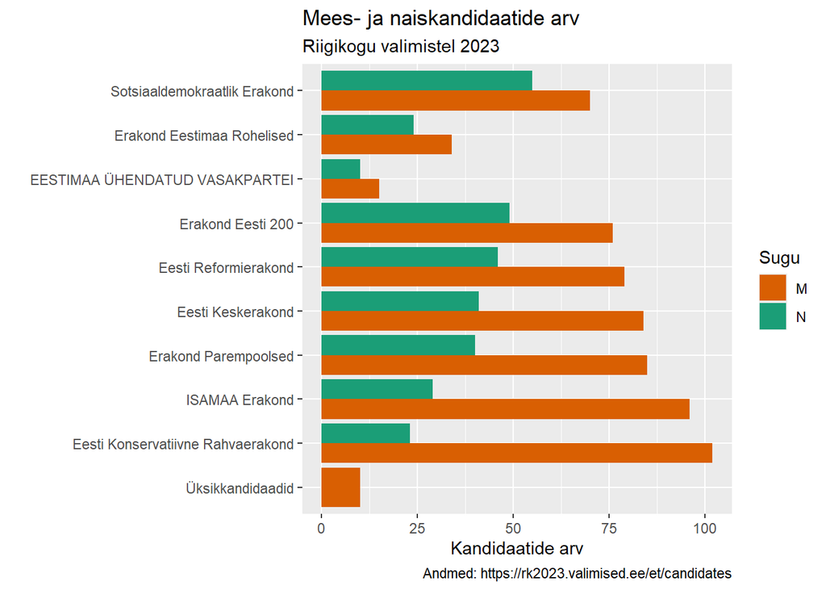

```r
ggplot(valimised, aes(y = nimekiri, fill = sugu)) +
  geom_bar(position = "dodge") +
  scale_fill_brewer(type = "qual", palette = 2, direction = -1) +
  scale_y_discrete(limits = naiskandidaatide_osakaal) +
  labs(x = "Kandidaatide arv",
       y = "",
       fill = "Sugu",
       title = "Mees- ja naiskandidaatide arv",
       subtitle = "Riigikogu valimistel 2023",
       caption = "Andmed: https://rk2023.valimised.ee/et/candidates")
```

`ggplot`’i graafikuid saab ka salvestada eraldi objektidesse, et neid taaskasutada. Salvestame meie praeguse joonise objekti nimega *p*.

```r
p <- ggplot(valimised, aes(y = nimekiri, fill = sugu)) +
  geom_bar(position = "dodge") +
  scale_fill_brewer(type = "qual", palette = 2, direction = -1) +
  scale_y_discrete(limits = naiskandidaatide_osakaal) +
  labs(x = "Kandidaatide arv",
       y = "",
       fill = "Sugu",
       title = "Mees- ja naiskandidaatide arv",
       subtitle = "Riigikogu valimistel 2023",
       caption = "Andmed: https://rk2023.valimised.ee/et/candidates")
```

### Harjuta

Laadi RStudiosse eelmistes praktikumides kasutatud küsimustik. Loo `ggplot`’i kiht, kus x-teljel oleks sünniaasta ja y-teljel oleks õpitud aastate arv.  
Kuva sünniaasta ja õpitud aastate arvu suhet hajuvusdiagrammil.  
Tähista erineva värviga need vastajad, kellel on kvantitatiivsete meetoditega kogemust, ja need, kellel ei ole. Kasuta kategooriate jaoks värve “grey45” ja “orange”.  
Lisa graafikule pealkiri “Õpitud aastate arv vastavalt sünniaastale”, alapealkiri “ja kokkupuutele kvantitatiivsete meetoditega” ning legendi pealkiri “Kogemused kvantitatiivsete meetoditega”.

## 5. kiht: graafiku üldine väljanägemine (*theme*)

Viiendal kihil võime täpsustada otseselt andmetega mitteseotud elementide väljanägemist graafikul funktsiooniga `theme()`. Selliste elementide hulka kuuluvad näiteks üldine teksti suurus, värv, font, paksus, paiknemine, graafiku tausta värv, graafiku piirjoonte olemasolu, paksus, värv, taustaruudustiku kuvamine, legendi asukoht jne. On terve hulk n-ö sisse-ehitatud teemasid, nt `theme_bw()`, `theme_grey()`, `theme_light()`, `theme_dark()`, `theme_minimal()`, `theme_classic()` jne.

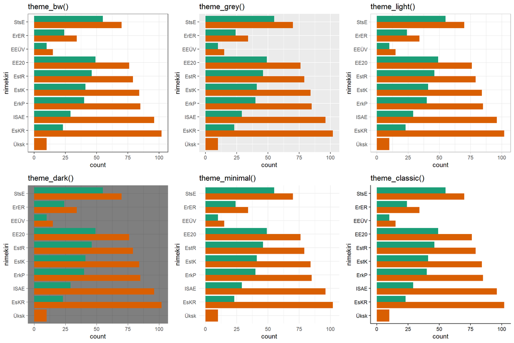

Vaata ka paketti [`ggthemes`](https://yutannihilation.github.io/allYourFigureAreBelongToUs/ggthemes/).

Teemat on aga võimalik ka ise kohandada, täpsustades kohandatavaid elemente funktsiooni `theme()` sees. Kohandatavaid elemente on palju:

**`axis.___`** telgede elemendid,  
**`legend.___`** legendi elemendid,  
**`panel.___`** joonise ala elemendid,  
**`plot.___`** terve graafiku elemendid  
jne.

Iga elemendi väljanägemist (v.a legendi paigutust) saab täpsustada ühega neljast `element`-funktsioonist:  
`element_blank()` - eemaldab mis tahes elemendi täielikult,  
`element_line()` - täpsustab joonte väljanägemist,  
`element_rect()` - täpsustab piirjoonte ja tausta väljanägemist,  
`element_text()` - täpsustab teksti väljanägemist.

Näiteks võib teha sellise teemakihi:

```r
theme(axis.text = element_text(size = 12, # telgede teksti suuruseks 12
                               color = "grey50"), # ja värviks hallikas
      legend.background = element_rect(fill = "transparent"), # legendi taust läbipaistvaks
      legend.position = "inside", # legend joonise ala sisse
      legend.position.inside = c(0.9, 0.9), # joonise ala sees oleva legendi suhteline asend x- ja y-teljel
      panel.background = element_rect(fill = "grey90"), # joonise üldala taustaks hallikas
      panel.grid = element_blank(), # kustuta taustaruudustik
      plot.subtitle = element_text(hjust = 0.5), # joonda joonise alapealkiri keskele
      plot.title = element_text(hjust = 0.5, # joonda joonise pealkiri keskele
                                face = "bold")) # ja kuva paksus kirjas
```

Kasutame nüüd objekti *p* salvestatud graafikut ning lisame sellele loodud teema.

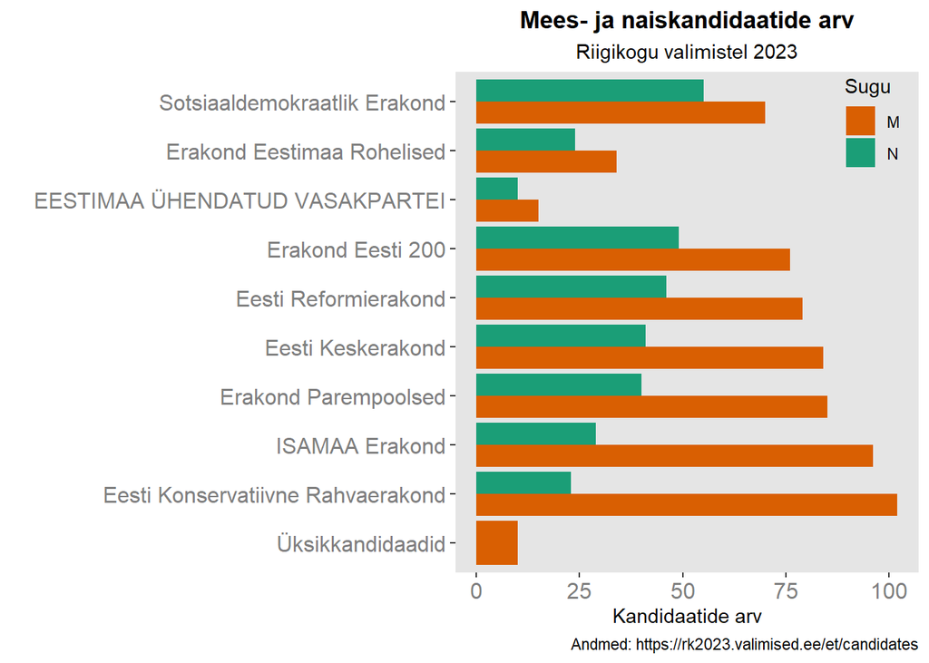

```r
p + theme(axis.text = element_text(size = 12, color = "grey50"),
          legend.background = element_rect(fill = "transparent"),
          legend.position = "inside",
          legend.position.inside = c(0.9, 0.9),
          panel.background = element_rect(fill = "grey90"),
          panel.grid = element_blank(),
          plot.subtitle = element_text(hjust = 0.5),
          plot.title = element_text(hjust = 0.5, face = "bold"))
```

Kui tahame legendi järjekorda muuta, et see vastaks joonise tulpade värvide järjekorrale, võime teha seda funktsioonis `guides()`.

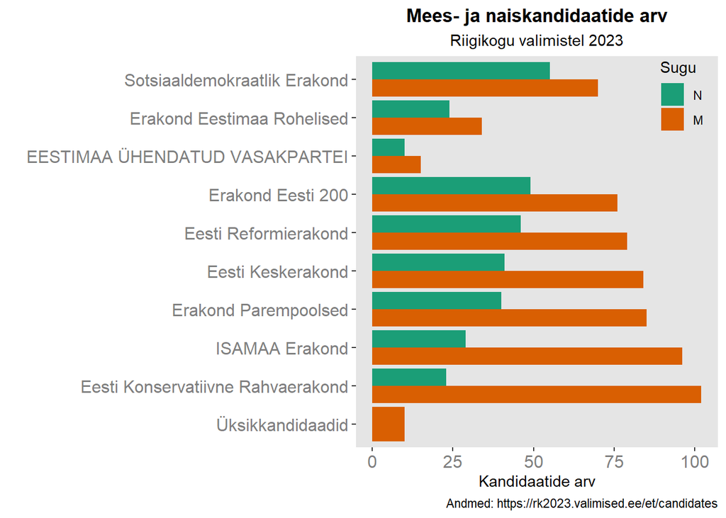

```r
p + theme(axis.text = element_text(size = 12, color = "grey50"),
          legend.background = element_rect(fill = "transparent"),
          legend.position = "inside",
          legend.position.inside = c(0.9, 0.9),
          panel.background = element_rect(fill = "grey90"),
          panel.grid = element_blank(),
          plot.subtitle = element_text(hjust = 0.5),
          plot.title = element_text(hjust = 0.5, face = "bold")) +
  guides(fill = guide_legend(reverse = T))
```

### Harjuta

Laadi RStudiosse eelmistes praktikumides kasutatud küsimustik. Loo `ggplot`’i kiht, kus x-teljel oleks sünniaasta ja y-teljel oleks õpitud aastate arv.  
Kuva sünniaasta ja õpitud aastate arvu suhet hajuvusdiagrammil.  
Tähista erineva värviga need vastajad, kellel on kvantitatiivsete meetoditega kogemust, ja need, kellel ei ole. Kasuta kategooriate jaoks värve “grey45” ja “orange”.  
Lisa graafikule pealkiri “Õpitud aastate arv vastavalt sünniaastale”, alapealkiri “ja kokkupuutele kvantitatiivsete meetoditega”, sobivad x- ja y-telje pealkirjad ning legendi pealkiri “Kogemused kvantitatiivsete meetoditega”.  
Lisa graafikule teema, mis värviks graafiku tausta värviga “aliceblue” ning joondaks pealkirja ja alapealkirja keskele.

## 6. kiht: paneelid (*facets*)

`ggplot`’i üks suuri eeliseid on paneelide funktsioon, mille abil on võimalik **jagada andmestik ühe või mitme tunnuse alusel alamandmestikeks** ning kuvada **kõikide alamandmestike graafikuid korraga** ühel joonisel.

Jagame näiteks tehtud graafiku kandidaatide hariduse põhjal paneelideks. Kasutame selleks funktsiooni `facet_wrap()`. Tunnus, mille alusel paneelid tehakse, lisatakse argumendina funktsiooni sisse.

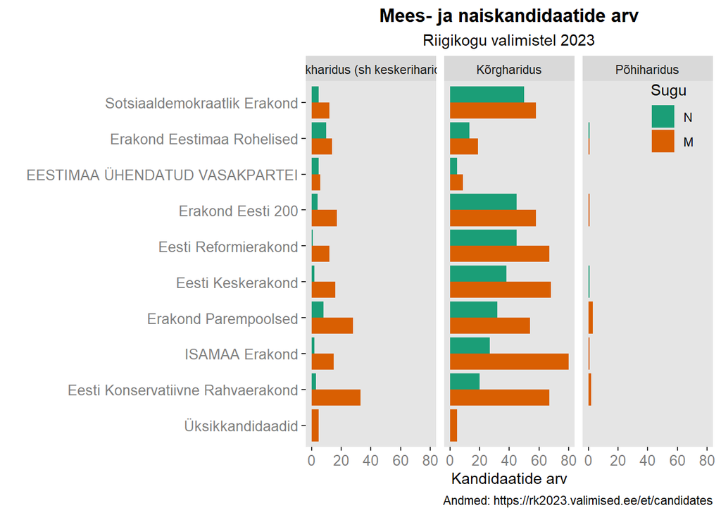

```r
ggplot(valimised, aes(y = nimekiri, fill = sugu)) +
  geom_bar(position = "dodge") +
  scale_fill_brewer(type = "qual", palette = 2, direction = -1) +
  scale_y_discrete(limits = naiskandidaatide_osakaal) +
  labs(x = "Kandidaatide arv",
       y = "",
       fill = "Sugu",
       title = "Mees- ja naiskandidaatide arv",
       subtitle = "Riigikogu valimistel 2023",
       caption = "Andmed: https://rk2023.valimised.ee/et/candidates") +
  theme(axis.text = element_text(size = 10, color = "grey50"),
        legend.background = element_rect(fill = "transparent"),
        legend.position = "inside",
        legend.position.inside = c(0.9, 0.9),
        panel.background = element_rect(fill = "grey90"),
        panel.grid = element_blank(),
        plot.subtitle = element_text(hjust = 0.5),
        plot.title = element_text(hjust = 0.5, face = "bold")) +
  guides(fill = guide_legend(reverse = T)) +
  facet_wrap("haridus") # Jagame andmestiku hariduse järgi paneelideks. NB! Tunnus jutumärkides!
```

Või vaatame joonisel hoopis osakaalusid:

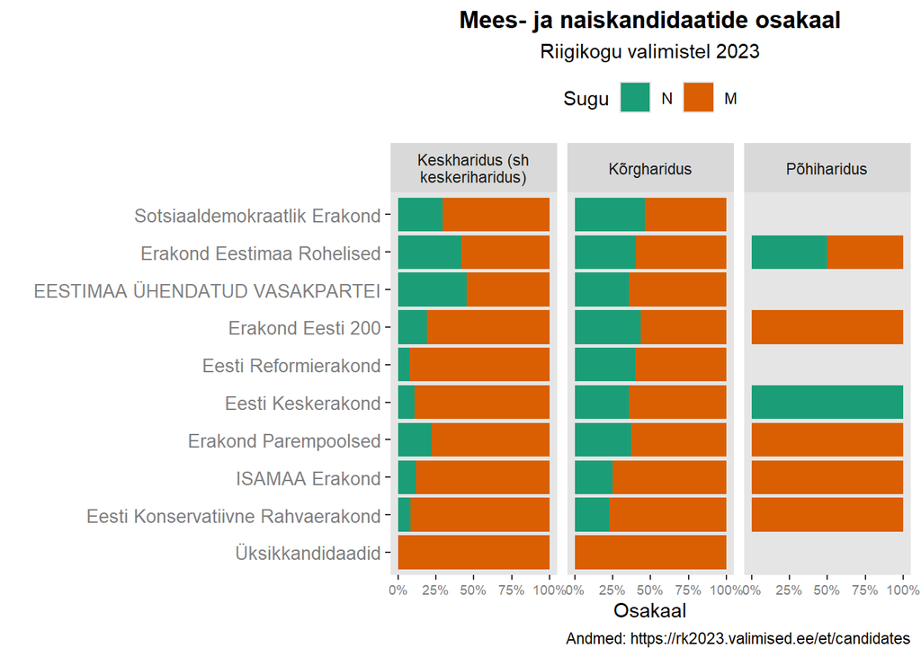

```r
ggplot(valimised, aes(y = nimekiri, fill = sugu)) +
  geom_bar(position = "fill") + # osakaalude tulpdiagramm
  scale_fill_brewer(type = "qual", palette = 2, direction = -1) +
  scale_y_discrete(limits = naiskandidaatide_osakaal) +
  scale_x_continuous(labels = scales::percent) + # x-telje tekst protsentideks
  labs(x = "Osakaal",
       y = "",
       fill = "Sugu",
       title = "Mees- ja naiskandidaatide osakaal",
       subtitle = "Riigikogu valimistel 2023",
       caption = "Andmed: https://rk2023.valimised.ee/et/candidates") +
  theme(axis.text = element_text(size = 10, color = "grey50"),
        axis.text.x = element_text(size = 7), # x-telje tekst väiksemas kirjas
        legend.background = element_rect(fill = "transparent"),
        legend.position = "top", # legend joonise kohale
        panel.background = element_rect(fill = "grey90"),
        panel.grid = element_blank(),
        plot.subtitle = element_text(hjust = 0.5),
        plot.title = element_text(hjust = 0.5, face = "bold")) +
  guides(fill = guide_legend(reverse = T)) +
  facet_wrap("haridus",
             labeller = label_wrap_gen()) # murra pikad paneelide pealkirjad eraldi ridadele
```

Joonist paneelideks jagav tunnus peab olema funktsioonis kas jutumärkides või kujul `~tunnus` (ilma jutumärkideta). Võib jagada ka mitme tunnuse järgi. Sel juhul on funktsiooni sees kas `c("esimenetunnus", "teinetunnus")` või `esimenetunnus~teinetunnus`. Alternatiiv funktsioonile `facet_wrap()` on `facet_grid()`, mis kuvab paneele pisut teistmoodi.

### Harjuta

Laadi RStudiosse eelmistes praktikumides kasutatud küsimustik. Loo `ggplot`’i kiht, kus x-teljel oleks sünniaasta ja y-teljel oleks õpitud aastate arv.  
Kuva sünniaasta ja õpitud aastate arvu suhet hajuvusdiagrammil.  
Tähista erineva värviga need vastajad, kellel on kvantitatiivsete meetoditega kogemust, ja need, kellel ei ole. Kasuta kategooriate jaoks värve “grey45” ja “orange”.  
Lisa graafikule pealkiri “Õpitud aastate arv vastavalt sünniaastale”, alapealkiri “ja kokkupuutele kvantitatiivsete meetoditega”, sobivad x- ja y-telje pealkirjad ning legendi pealkiri “Kogemused kvantitatiivsete meetoditega”.  
Lisa graafikule teema, mis värviks graafiku tausta värviga “aliceblue” ning joondaks pealkirja ja alapealkirja keskele.  
Näita erinevatel paneelidel tee- ja kohvijoojate vastuseid. Jaga kuvatavaid andmeid veel väiksemateks gruppideks vastavalt lemmikloomale. Võrdle `facet_wrap()` ja `facet_grid()` väljundeid.

Võrdle tulemust ChatGPT pakutud koodiga:

[figure not shown]

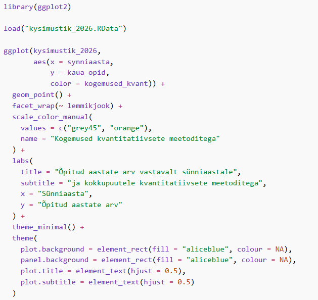

```r
# Laadi vajalikud paketid
library(ggplot2)

# Laadi andmestik
load("kysimustik_2026.RData")

# Koosta graafik
ggplot(kysimustik,
       aes(x = synniaasta,
           y = kaua_opid,
           color = kogemused_kvant)) +
  geom_point() + # Hajuvusdiagramm
  facet_wrap(~ lemmikjook) + # Tee- ja kohvijoojate eraldi paneelid
  scale_color_manual(
    values = c("grey45", "orange"), # Värvid kategooriatele
    name = "Kogemused kvantitatiivsete meetoditega"
  ) +
  labs(
    title = "Õpitud aastate arv vastavalt sünniaastale",
    subtitle = "ja kokkupuutele kvantitatiivsete meetoditega",
    x = "Sünniaasta",
    y = "Õpitud aastate arv"
  ) +
  theme_minimal() + # Minimaalne teema
  theme(
    plot.background = element_rect(fill = "aliceblue", colour = NA), # Joonise taustavärv
    panel.background = element_rect(fill = "aliceblue", colour = NA), # Paneelide taustavärv
    plot.title = element_text(hjust = 0.5), # Pealkiri keskele
    plot.subtitle = element_text(hjust = 0.5) # Alapealkiri keskele
  )
```

## Eelmiste kordade graafikud

Kuna kohandatavaid graafiku elemente on ggplotis väga palju, on sellega võimalik matkida sisuliselt mis tahes graafikute stiile, sh baaspaketi graafikat.

### Karpdiagramm

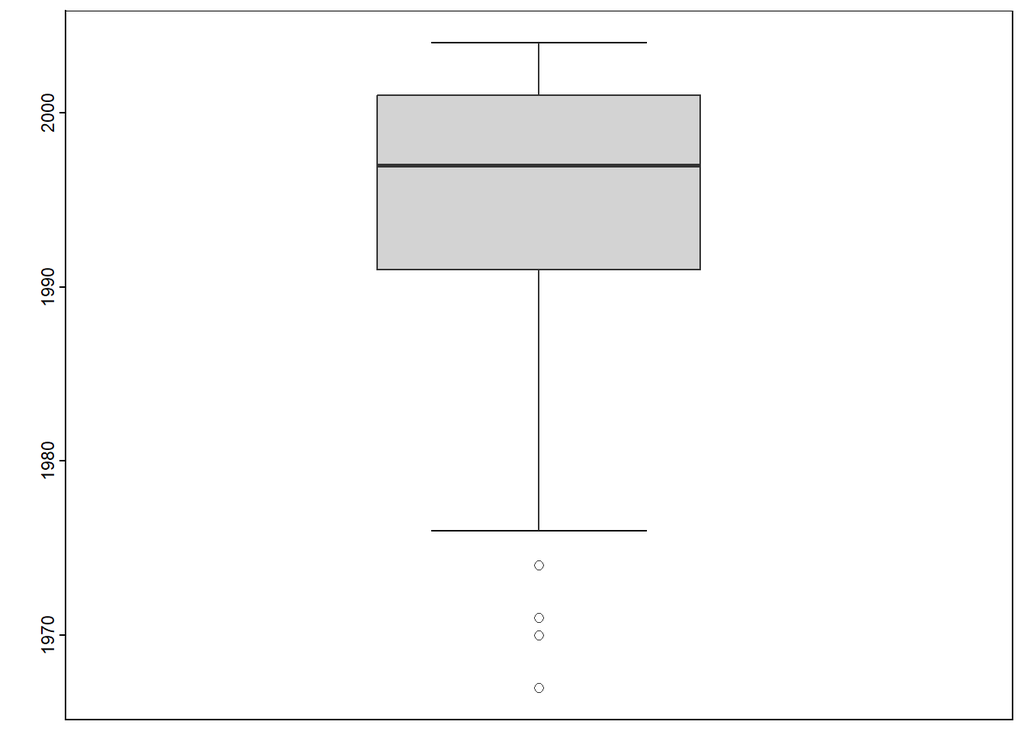

```r
# Sünniaasta karpdiagramm
ggplot(kysimustik,
       aes(y = synniaasta)) +
  stat_boxplot(geom = "errorbar", # vurrud tuleb joonistada eraldi funktsiooniga
               width = 0.5) + # vurru laius 50% oma tavalaiusest
  geom_boxplot(outlier.shape = 1, # muuda erindi sümbolit
               outlier.size = 2,  # tee erindi sümbol suuremaks
               fill = "lightgrey") + # määra karbi täitevärv
  scale_y_continuous(breaks = seq(1970, 2000, 10)) + # y-skaala 1970-st 2000-ni 10-aastaste intervallidena
  labs(y = "") + # y-teljelt tekst ära
  theme_classic() +
  theme(axis.text.y = element_text(angle = 90, # y-telje tekst 90-kraadise nurga alla
                                   hjust = 0.5), # y-telje tekst joondada sakkidega
        axis.text.x = element_blank(), # ära näita x-telje teksti
        axis.ticks.x = element_blank(), # ära näita x-telje sakke
        panel.background = element_rect(color = "black")) + # joonise alale must kast ümber
  xlim(-1, 1) # lisa karbist vasakule ja paremale natuke tühja ruumi
```

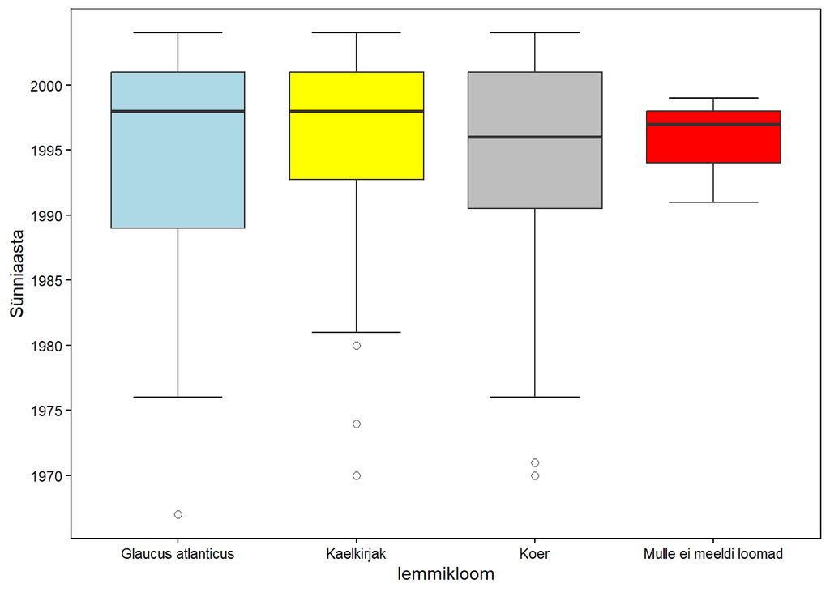

```r
# Lemmiklooma ja sünniaasta karpdiagramm
ggplot(kysimustik,
       aes(x = lemmikloom, y = synniaasta)) +
  stat_boxplot(geom = "errorbar", # vurrud
               width = 0.5) + # vurrud 50% oma tavalaiusest
  geom_boxplot(fill = c("lightblue", # kastide värvid
                        "yellow", # NB! ei ole seotud andmestiku tunnusega
                        "grey", "red"),
               outlier.shape = 1, # erindi kuju
               outlier.size = 2) + # erindi suurus
  scale_y_continuous(breaks = seq(1970, 2000, 5)) + # y-skaala 1970-st 2000-ni 5-aastaste intervallidena
  labs(y = "Sünniaasta") + # muuda y-telje pealkirja
  theme_classic() +
  theme(panel.background = element_rect(color = "black"))
```

### Histogramm

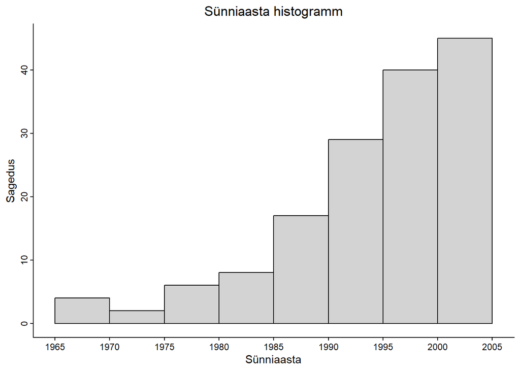

```r
# Sünniaasta histogramm
ggplot(kysimustik,
       aes(x = synniaasta)) +
  geom_histogram(binwidth = 5, # sagedusklassi ulatus 5 ühikut (aastat)
                 boundary = 0, # aitab antud juhul joondada klasse skaala numbritega
                 color = "black", # klasside ääred mustad
                 fill = "lightgrey") + # klasside sisu helehall
  scale_x_continuous(breaks = seq(1965, 2005, 5)) + # x-skaala 1965-st 2005-ni 5-aastaste intervallidena
  labs(title = "Sünniaasta histogramm",
       x = "Sünniaasta",
       y = "Sagedus") +
  theme_classic() +
  theme(plot.title = element_text(hjust = 0.5), # graafiku pealkiri keskele
        axis.text.y = element_text(angle = 90, # y-telje väärtused 90-kraadise nurga alla
                                   hjust = 0.5)) # y-telje väärtused joondada sakkidega
```

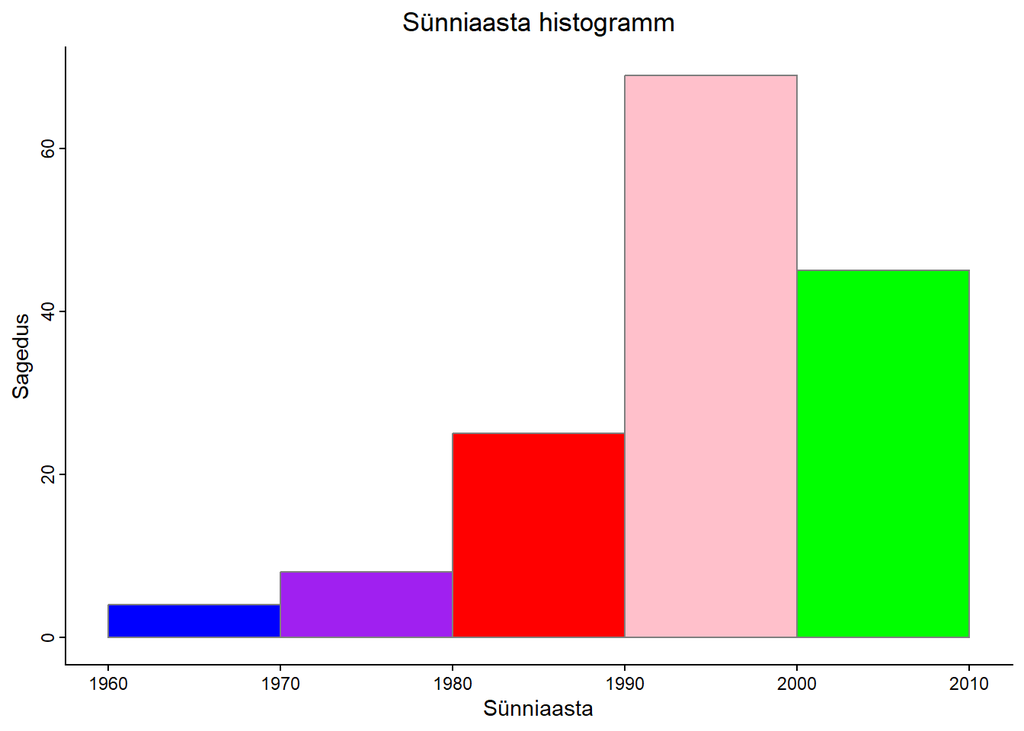

```r
# Värviline sünniaasta histogramm
ggplot(kysimustik,
       aes(x = synniaasta)) +
  geom_histogram(binwidth = 10, # sagedusklassi ulatus 10 ühikut
                 boundary = 0, # joonda klassid skaalaga
                 color = "grey50", # klasside ääred hallid
                 fill = c("blue", "purple", "red", "pink", "green")) + # klasside sisu viie erineva värviga
  scale_x_continuous(breaks = seq(1960, 2010, 10)) + # x-skaala 1960-st 2010-ni 10-aastaste intervallidena
  labs(title = "Sünniaasta histogramm",
       x = "Sünniaasta",
       y = "Sagedus") +
  theme_classic() +
  theme(plot.title = element_text(hjust = 0.5), # pealkiri keskele
        axis.text.y = element_text(angle = 90, hjust = 0.5)) # y-telje teksti pöörata ja joondada sakkidega
```

### Hajuvusdiagramm

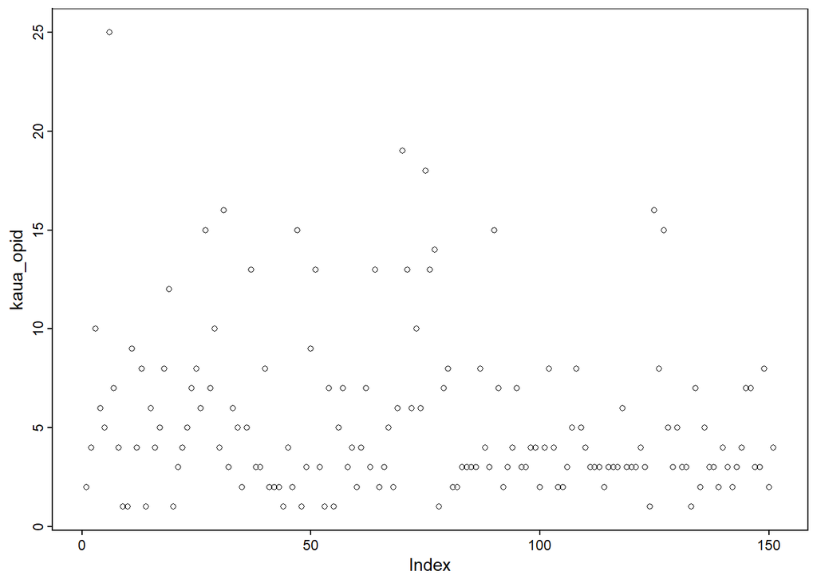

```r
# Ülikoolis õpitud aastate hajuvusdiagramm
ggplot(kysimustik,
       aes(y = kaua_opid,
           x = seq_along(kaua_opid))) + # vektor, mis koosneb arvudest 1...151
  geom_point(shape = 1, # punktide kuju
             size = 1.5) + # punktide suurus
  labs(x = "Index") + # x-telje pealkiri
  theme_classic() +
  theme(panel.background = element_rect(color = "black"),
        axis.text.y = element_text(angle = 90, # y-telje tekst 90-kraadise nurga alla
                                   hjust = 0.5)) # y-telje tekst joondada sakkidega
```

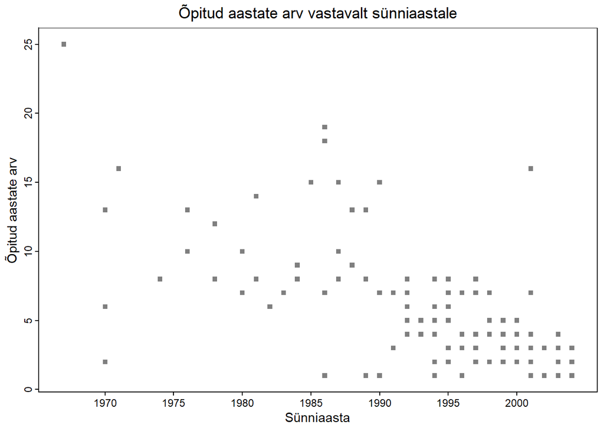

```r
# Õpitud aastate ja sünniaasta hajuvusdiagramm
ggplot(kysimustik,
       aes(x = synniaasta,
           y = kaua_opid)) +
  geom_point(shape = 15, # punktide kuju
             color = "grey50", # punktide värv
             size = 1.5) + # punktide suurus
  scale_x_continuous(breaks = seq(1970, 2000, 5)) + # y-skaala 1970-st 2000-ni 5-aastaste intervallidena
  labs(x = "Sünniaasta",
       y = "Õpitud aastate arv",
       title = "Õpitud aastate arv vastavalt sünniaastale") +
  theme_classic() +
  theme(panel.background = element_rect(color = "black"),
        axis.text.y = element_text(angle = 90,
                                   hjust = 0.5),
        plot.title = element_text(hjust = 0.5))
```

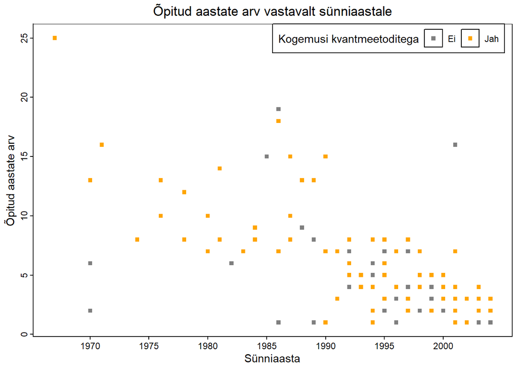

```r
ggplot(kysimustik,
       aes(x = synniaasta,
           y = kaua_opid,
           color = kogemused_kvant)) + # punktid värvitud andmestiku tunnuse järgi
  geom_point(shape = 15,
             size = 1.5) +
  scale_x_continuous(breaks = seq(1970, 2000, 5)) +
  scale_color_manual(name = "Kogemusi kvantmeetoditega", # värvilegendi pealkiri
                     values = c("grey50", "orange")) + # kategooriate värvid
  labs(x = "Sünniaasta",
       y = "Õpitud aastate arv",
       title = "Õpitud aastate arv vastavalt sünniaastale") +
  theme_classic() +
  theme(panel.background = element_rect(color = "black"),
        axis.text.y = element_text(angle = 90,
                                   hjust = 0.5),
        plot.title = element_text(hjust = 0.5),
        legend.direction = "horizontal", # legend horisontaalne
        legend.position = c(0.5, 1), # legend algab x-telje 50% peal ning lõppeb y-telje 100% peal
        legend.justification = c(0,1), # legendi asetus
        legend.background = element_rect(color = "black")) # legendile must piirjoon ümber
```